# Statistics in R

## Today's session:

- From LM to GLM
- The GLM in R
- Log-linear model
- Binomial model

## Generalized linear models

## From LM to GLM

Remember the airquality regression problem:

\(Ozone = Temp * Wind + Solar\)

We found that the residuals were not well distributed, because of ozone concentration being bounded to positive values. We transformed the response to overcome this problem:

\(log(Ozone) = Temp * Wind + Solar\)

However, transforming the response can make the interpretation of the model challenging, as well as the back-transformation of standard errors and confidence intervals can be difficult.

## From LM to GLM

The idea behind GLMs is that we transform a linear predictor:

\(\theta_i = \bf{X_i}\beta = \beta_{0} + \beta_{1} x_{i1} + ... + \beta_{k} x_{ik}\)

via a so-called *link-function* to match the data:

\(\hat{y_i} = g^{-1}(\theta_i) = g^{-1}(\bf{X_i}\beta)\)

For a simple-linear regression, the link-function is the so-called *identity* link, that is \(g(\theta) = \theta\).

Further, we also have to assume a data distribution, which for linear regression is Gaussian with zero mean and a variance of \(\sigma\). The linear model can thus be written as:

\(y_i \sim N(\bf{X_i}\beta, \sigma)\)

## From LM to GLM

Running a simple linear regression using `glm()` and comparing to `lm()`:

```r
fit.lm <- lm(Ozone ~ Temp * Wind, data = na.omit(airquality))

fit.glm <- glm(Ozone ~ Temp * Wind, data = na.omit(airquality), family = gaussian(link = "identity"))
```

## From LM to GLM

Running a simple linear regression using `glm()` and comparing to `lm()`:

```r
coef(fit.lm)
```

```
## (Intercept)        Temp        Wind   Temp:Wind
## -239.891827    4.000528   13.597458   -0.217276
```

```r
coef(fit.glm)
```

```
## (Intercept)        Temp        Wind   Temp:Wind
## -239.891827    4.000528   13.597458   -0.217276
```

## From LM to GLM

```
##
## Call:
## glm(formula = Ozone ~ Temp * Wind, family = gaussian(link = "identity"),
##     data = na.omit(airquality))
##
## Deviance Residuals:
##     Min       1Q   Median       3Q      Max
## -40.930  -11.193   -3.034    8.193   97.456
##
## Coefficients:
##              Estimate Std. Error t value Pr(>|t|)
## (Intercept) -239.8918    48.6200  -4.934 2.97e-06 ***
## Temp           4.0005     0.5935   6.741 8.26e-10 ***
## Wind          13.5975     4.2835   3.174 0.001961 **
## Temp:Wind     -0.2173     0.0545  -3.987 0.000123 ***
## ---
## Signif. codes:  0 '***' 0.001 '**' 0.01 '*' 0.05 '.' 0.1 ' ' 1
##
## (Dispersion parameter for gaussian family taken to be 414.8987)
##
##     Null deviance: 121802  on 110  degrees of freedom
## Residual deviance:  44394  on 107  degrees of freedom
## AIC: 990.04
##
## Number of Fisher Scoring iterations: 2
```

## From LM to GLM

Instead of transforming the response, we now define a link-function linking the linear model to the response:

```r
fit.glm <- glm(Ozone ~ Temp, data = na.omit(airquality), family = gaussian(link = "log"))
```

The link-function is \(g(\theta) = ln(\theta)\) and the inverse is \(g^{-1}(\theta) = e^{\theta}\). The data distribution is still assumed to be normal and the model can also be written as:

\(y_i \sim N(exp(\bf{X_i}\beta), \sigma)\)

Note the difference to a LM with log-transformed preditor:

\(y_i \sim exp(N(\bf{X_i}\beta, \sigma))\)

## From LM to GLM

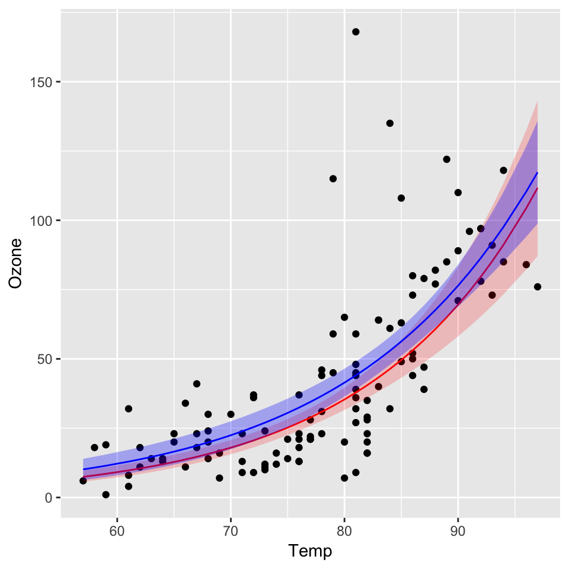

## From LM to GLM

What are the advantages of a GLM?

- Predictions (and confidence intervals) are calculated in the original data space, not in a transformed data space
- We can select any link function fitting many data problems (bounded to positive, bounded to [0,1], …)
- We can specify the data distribution (think of counts, success/failure, rates, …)

## The GLM in R

## The GLM in R

We make use of a new data set:

```r
dat <- read.table("Data/logistic.txt", sep = "\t", header = TRUE)

head(dat)
```

```
##   logdose  n dead product
## 1     0.1 18    0       A
## 2     0.2 16    4       A
## 3     0.3 21    7       A
## 4     0.4 19    6       A
## 5     0.5 16    5       A
## 6     0.6 20   10       A
```

```r
p <- ggplot(dat, aes(x = logdose, y = dead / n, col = product)) +
  geom_point() +
  scale_color_brewer(palette = "Set1") # See colorbrewer.org for palettes
```

## The GLM in R

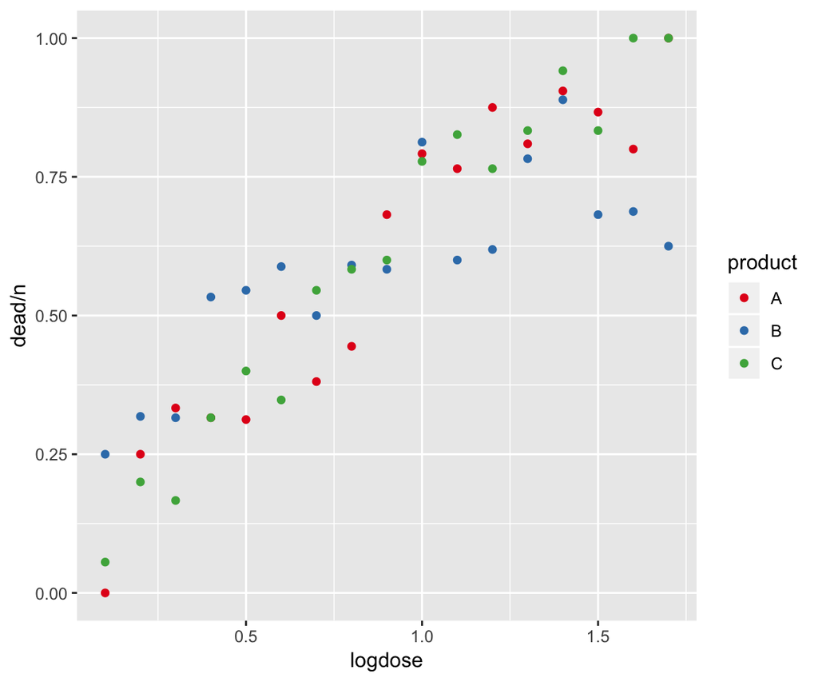

## The GLM in R

We now aim to model the mortality-rate (boundede between 0 and 1) in response to the dose of a toxin. For doing so, we need to combine the dead and surviving cells using `cbind()`:

```r
fit <- glm(cbind(dead, n - dead) ~ logdose,
           data = dat,
           family = binomial(link = "logit"))
```

As link function we choose a logit-link (bounded between 0 and 1) and we assume the data to be binomial distributed (k successes given n trials).

## The GLM in R

```
##
## Call:
## glm(formula = cbind(dead, n - dead) ~ logdose, family = binomial(link = "logit"),
##     data = dat)
##
## Deviance Residuals:
##      Min        1Q    Median        3Q       Max
## -3.14262  -0.56909   0.06357   0.83762   2.29354
##
## Coefficients:
##             Estimate Std. Error z value Pr(>|z|)
## (Intercept)  -1.5980     0.1555  -10.27   <2e-16 ***
## logdose       2.3179     0.1699   13.64   <2e-16 ***
## ---
## Signif. codes:  0 '***' 0.001 '**' 0.01 '*' 0.05 '.' 0.1 ' ' 1
##
## (Dispersion parameter for binomial family taken to be 1)
##
##     Null deviance: 311.241  on 50  degrees of freedom
## Residual deviance:  72.387  on 49  degrees of freedom
## AIC: 223.39
##
## Number of Fisher Scoring iterations: 4
```

## The GLM in R

We can create predictions from the model and overlay them on the scatterplot:

```r
predictions <- data.frame(logdose = dat$logdose,
                          prediction = predict(fit, type = "response")) # Alternatively type = "link"

p <- ggplot(dat, aes(x = logdose, y = dead/n)) +
  geom_point() +
  geom_line(data = predictions, aes(x = logdose, y = prediction))
```

## The GLM in R

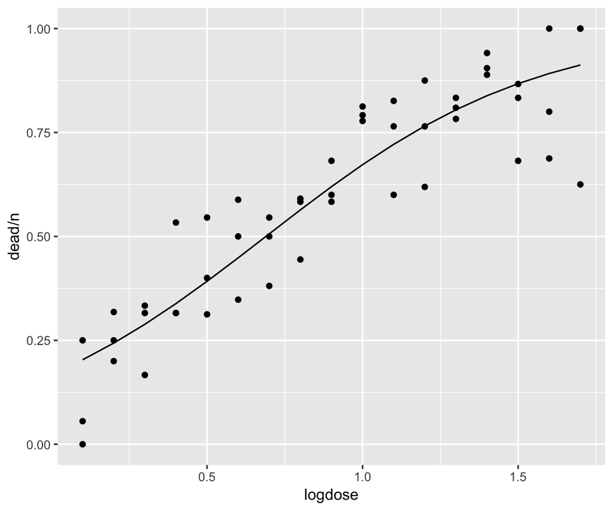

## The GLM in R

Let us see if the mortality varies by toxin:

```r
fit <- glm(cbind(dead, n - dead) ~ logdose * product,
           data = dat,
           family = binomial(link = "logit"))
```

## The GLM in R

```
##
## Call:
## glm(formula = cbind(dead, n - dead) ~ logdose * product, family = binomial(link = "logit"),
##     data = dat)
##
## Deviance Residuals:
##      Min        1Q    Median        3Q       Max
## -2.39800  -0.60734   0.09695   0.65920   1.69300
##
## Coefficients:
##                  Estimate Std. Error z value Pr(>|z|)
## (Intercept)       -2.0410     0.3034  -6.728 1.72e-11 ***
## logdose            2.8768     0.3432   8.383  < 2e-16 ***
## productB           1.2920     0.3845   3.360  0.00078 ***
## productC          -0.3079     0.4308  -0.715  0.47469
## logdose:productB  -1.6457     0.4220  -3.899 9.65e-05 ***
## logdose:productC   0.4318     0.4898   0.882  0.37793
## ---
## Signif. codes:  0 '***' 0.001 '**' 0.01 '*' 0.05 '.' 0.1 ' ' 1
##
## (Dispersion parameter for binomial family taken to be 1)
##
##     Null deviance: 311.241  on 50  degrees of freedom
## Residual deviance:  42.305  on 45  degrees of freedom
## AIC: 201.31
##
## Number of Fisher Scoring iterations: 4
```

## The GLM in R

We can create predictions from the model and overlay them on the scatterplot:

```r
library(effects)

predictions <- effect("logdose:product", mod = fit, xlevels = list(logdose = seq(0, 2, length.out = 100)))
predictions <- as.data.frame(predictions)

p <- ggplot() +
  geom_point(data = dat, aes(x = logdose, y = dead/n, col = product)) +
  geom_ribbon(data = predictions, aes(x = logdose, ymin = lower, ymax = upper, fill = product), alpha = 0.2) +
  geom_line(data = predictions, aes(x = logdose, y = fit, col = product)) +
  scale_fill_brewer(palette = "Set1") +
  scale_color_brewer(palette = "Set1")
```

## The GLM in R

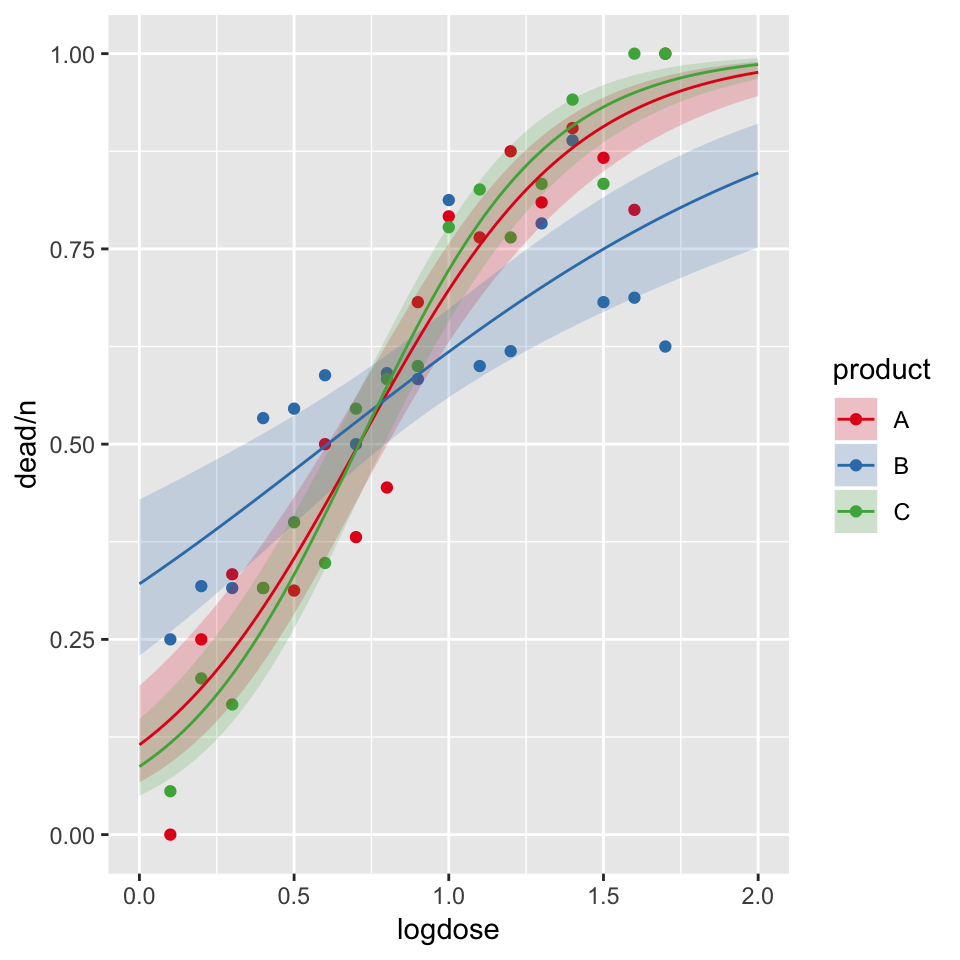

## GLM in R

We can check the residuals using the `residuals()` function. However, note that we need to look at the scaled residuals as the variance changes with the mean!

```r
resid <- data.frame(fitted = fitted(fit),
                    residuals = residuals(fit, type = "pearson")) # Pearson residuals

p1 <- ggplot(resid, aes(x = fitted, y = residuals)) +
  geom_point()

p2 <- ggplot(resid, aes(sample = scale(residuals))) +
  stat_qq() +
  geom_abline(intercept = 0, slope = 1)
```

## The GLM in R

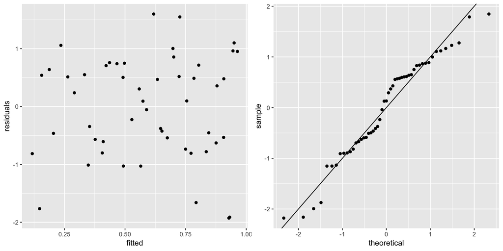

## Assignment

There is no R assignment this week. However, please recap the theory and use of GLMs. We will do additional examples - with increasing complexity - next week and the week after next week.